# FacialRecognition

Xinli

April 9, 2016

```r
# make sure R is in the proper working directory
setwd("~/Desktop/datamining-hw")
# include the relevant libraries
library(rmarkdown)
library(pixmap)
library(class)
```

Load the views P00A+000E+00, P00A+005E+10, P00A+005E-10, and P00A+010E+00 for all subjects in the CroppedYale directory. Convert each photo to a vector; store the collection as a matrix where each row is a photo. Give this matrix the name face_matrix. For each image, record the subject number and view in a data frame. The subject numbers will be used as our data labels

```r
pic_list = 1:38
views = c('P00A+000E+00', 'P00A+005E+10', 'P00A+005E-10', 'P00A+010E+00' )
# load the data and save it as a matrix with the name face_matrix

# get directory structure
dir_list_1 = dir(path="CroppedYale/",all.files=FALSE)
dir_list_2 = dir(path="CroppedYale/",all.files=FALSE,recursive=TRUE)

# Find the total number of pixels in a picture

# Pre-allocate a matrix with dimensions (number of pictures) x (number of pixels per picture)
face_matrix = vector()
subject <- vector()
view <- vector()
# Load all of the pictures
for (i in pic_list){
    for (j in 1:4) {
        filename = sprintf("CroppedYale/%s/%s_%s.pgm",
                           dir_list_1[pic_list[i]] , dir_list_1[pic_list[i]] , views[j])
        face = read.pnm(filename)
        face_vector = getChannels(face)
        face_vectors = as.vector(face_vector)
        face_matrix = rbind(face_matrix, face_vectors)
        subject <- c(subject, i)
        view <- c(view, j)
    }
}

# Get the size of the matrix for use later
fm_size = dim(face_matrix)
# Use 4/5 of the data for training, 1/5 for testing
ntrain = floor(fm_size[1]*4/5) # Number of training obs
ntest = fm_size[1]-ntrain # Number of testing obs
set.seed(1) # Set pseudo-random numbers getting the same output
ind_train = sample(1:fm_size[1],ntrain) # Training indices
ind_test = c(1:fm_size[1])[-ind_train] # Testing indices
```

Do PCA on training set and use the first 25 scores to represent the data. Project testing data onto the first 25 loadings. Use 1NN classification in the space of the first 25 scores to identify the subject for each testing observation.

```r
train <- face_matrix[ind_train,]
subject_train <- subject[ind_train]
test <- face_matrix[ind_test, ]
subject_test <- subject[ind_test]
#####Do PCA on training set and use the first 25 scores to represent data
train_mat_mean <- colMeans(train)
train_mat_center <- scale(train, center = TRUE, scale = F)
mat_pca <- prcomp(train_mat_center)
#Project testing data onto the first 25 loadings
#so that it is represented by the first 25 scores. Do not rescale the scores.
train_loadings <- mat_pca$rotation[, 1:25]
test_mean <- t(apply(test, 1, function(x) {x- train_mat_mean }))
test_score <- test_mean%*%train_loadings
#Use 1NN classification in the space of the first 25 scores to identify the subject for each testing observation
train_score <- mat_pca$x[,1:25]
test_hat <- knn(train_score, test_score, subject_train, 1)
misidentified <- sum(test_hat != subject_test)
misidentified
```

```
## [1] 0
```

The misclassification rate is 0

Using other pictures

```r
# Use different lighting conditions
#Builing a new matrix and using PCA and kNN for classification again
pic_list = 1:38
views_2 = c('P00A-035E+15', 'P00A-050E+00', 'P00A+035E+15', 'P00A+050E+00')

dir_list_1 = dir(path="CroppedYale/",all.files=FALSE)
dir_list_2 = dir(path="CroppedYale/",all.files=FALSE,recursive=TRUE)

# Find the total number of pixels in a picture

# Pre-allocate a matrix with dimensions (number of pictures) x (number of pixels per picture)
face_matrix_2 <- vector()
subject_2 <- vector()
view_2 <- vector()
# Load all of the pictures
for (i in pic_list){
    for (j in 1:4) {
        filename = sprintf("CroppedYale/%s/%s_%s.pgm",
                           dir_list_1[pic_list[i]] , dir_list_1[pic_list[i]] , views_2[j])
        face = read.pnm(filename)
        face_vector = getChannels(face)
        face_vectors = as.vector(face_vector)
        face_matrix_2 = rbind(face_matrix_2, face_vectors)
        subject_2 <- c(subject_2, i)
        view_2 <- c(view_2, j)
    }
}
fm_2_size = dim(face_matrix_2)
# Use 4/5 of the data for training, 1/5 for testing
ntrain_2 = floor(fm_2_size[1]*4/5)
ntest_2 = fm_2_size[1]-ntrain_2
set.seed(2) # Set pseudo-random numbers
ind_train_2 = sample(1:fm_2_size[1],ntrain_2)
ind_test_2 = c(1:fm_2_size[1])[-ind_train_2]

train_2 <- face_matrix_2[ind_train_2,]
subject_2_train <- subject_2[ind_train_2]
test_2 <- face_matrix_2[ind_test_2, ]
subject_2_test <- subject_2[ind_test_2]
#####Do PCA on training set and use the first 25 scores to represent data
train_2_mean <- colMeans(train_2)
train_2_center <- scale(train_2, center = TRUE, scale = F)
mat_pca_2 <- prcomp(train_2_center)
#Project testing data onto the first 25 loadings
#so that it is represented by the first 25 scores. Do not rescale the scores.
train_loadings_2 <- mat_pca_2$rotation[, 1:25]
test_mean_2 <- t(apply(test_2, 1, function(x) {x- train_2_mean }))
test_score_2 <- test_mean_2%*%train_loadings_2
#Use 1NN classification in the space of the first 25 scores to identify the subject for each testing observation
train_score_2 <- mat_pca_2$x[,1:25]
test_hat_2 <- knn(train_score_2, test_score_2, subject_2_train, 1)
misidentified_2 <- sum(test_hat_2 != subject_2_test)
misidentified_2
```

```
## [1] 27
```

at this time, as many as 27 are misidentified Plot four subject photos that are misidentified next to the 1NN photo prediction

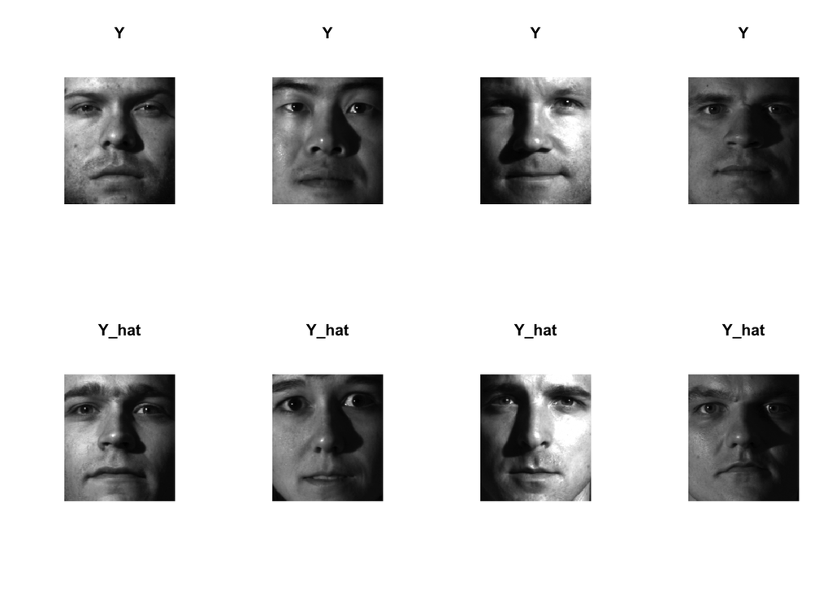

```r
par(mfrow=c(2,4))
plot(pixmapGrey(matrix(test_2[test_hat_2 != subject_2_test, ][1, ], nrow = dim(face_vector)[1])), main="Y")
plot(pixmapGrey(matrix(test_2[test_hat_2 != subject_2_test, ][2, ], nrow = dim(face_vector)[1])), main="Y")
plot(pixmapGrey(matrix(test_2[test_hat_2 != subject_2_test, ][3, ], nrow = dim(face_vector)[1])), main="Y")
plot(pixmapGrey(matrix(test_2[test_hat_2 != subject_2_test, ][4, ], nrow = dim(face_vector)[1])), main="Y")

dist.train.test <- as.matrix(dist(face_matrix_2))[ind_test_2, ind_train_2][test_hat_2 != subject_2_test, ][1:4, ]
train.row <- apply(dist.train.test, 1, which.min)
plot(pixmapGrey(matrix(train_2[train.row[1], ], nrow = dim(face_vector)[1])), main="Y_hat")
plot(pixmapGrey(matrix(train_2[train.row[2], ], nrow = dim(face_vector)[1])), main="Y_hat")
plot(pixmapGrey(matrix(train_2[train.row[3], ], nrow = dim(face_vector)[1])), main="Y_hat")
plot(pixmapGrey(matrix(train_2[train.row[4], ], nrow = dim(face_vector)[1])), main="Y_hat")
```

```r
incorrextly <- vector()
for (i in 3:12){
    fm_2_size = dim(face_matrix_2)
    # Use 4/5 of the data for training, 1/5 for testing
    ntrain_2 = floor(fm_2_size[1]*4/5)
    ntest_2 = fm_2_size[1]-ntrain_2
    set.seed(i) # Set pseudo-random numbers
    ind_train_2 = sample(1:fm_2_size[1],ntrain_2)
    ind_test_2 = c(1:fm_2_size[1])[-ind_train_2]

    train_2 <- face_matrix_2[ind_train_2,]
    subject_2_train <- subject_2[ind_train_2]
    test_2 <- face_matrix_2[ind_test_2, ]
    subject_2_test <- subject_2[ind_test_2]
    #####Do PCA on training set and use the first 25 scores to represent data
    train_2_mean <- colMeans(train_2)
    train_2_center <- scale(train_2, center = TRUE, scale = F)
    mat_pca_2 <- prcomp(train_2_center)
    #Project testing data onto the first 25 loadings
    #so that it is represented by the first 25 scores. Do not rescale the scores.
    train_loadings_2 <- mat_pca_2$rotation[, 1:25]
    test_mean_2 <- t(apply(test_2, 1, function(x) {x- train_2_mean }))
    test_score_2 <- test_mean_2%*%train_loadings_2
    #Use 1NN classification in the space of the first 25 scores to identify the subject for each testing observation
    train_score_2 <- mat_pca_2$x[,1:25]
    test_hat_2 <- knn(train_score_2, test_score_2, subject_2_train, 1)
    misidentified_2 <- sum(test_hat_2 != subject_2_test)
    incorrextly <- c(incorrextly, misidentified_2)
}
incorrextly
```

```
##  [1] 27 22 25 25 22 28 24 21 23 27
```

The misidentified rate is pretty high. This suggest that PCA lost many information of the data.